# Banks Exploritory and Analysing

### Comparing the banks with Hashtags:

**boubyan hashtags**

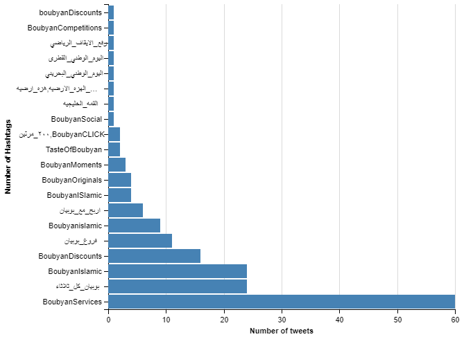

- they use BoubyanService and بوبيان كل ثلاثاء frequently

**KFH hashtags**

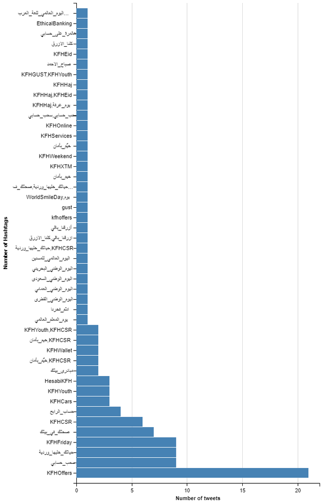

- we notice here than bank KFH tweets a veriaty of different hashtages that are more than bank boubyan but not as frequent as them

**NBK hashtags**

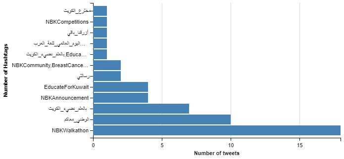

- bank NBK tweets the least number of hastages and the least frequent times.

### Comparing retweets of hashatges made by Bank accounts:

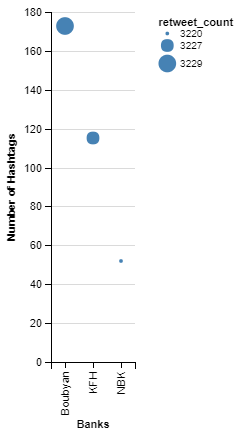

- we notice that bank boubyan gets the most retweets for their hashtages because of their active followers.

### Let's see which hashtages gets the most retweets:

**Boubyan Bank**

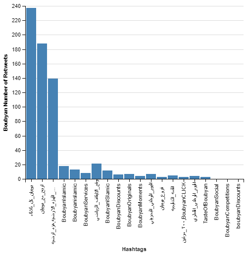

**KFH**

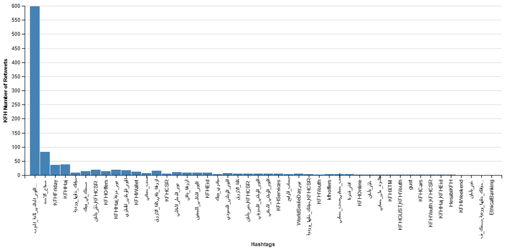

**NBK**

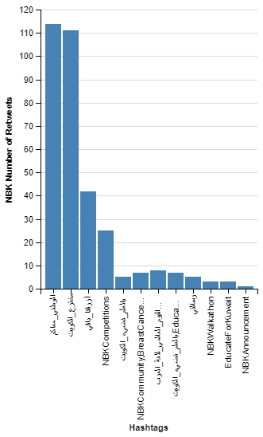

**Notice:**

- we noticed the most retweets for bank boubyan are for the hashtages that talk about prizes and draws and lottery winners they market their tweets by asking for retweets to pick winners and for their to be interactivity between them and their followers.

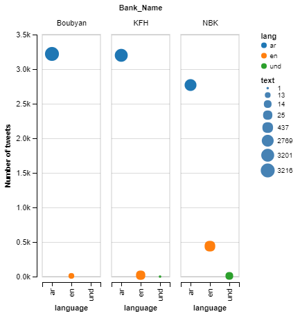

**Notice:**

- we can notice that most most's tweets are in arabic but the NBK tweets in english more than the other banks.

### Looking into which source these accounts tweet from:

**Boubyan Bank**

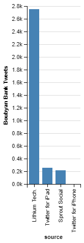

**KFH**

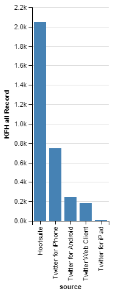

**NBK**

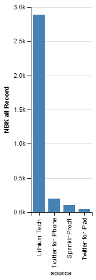

**Notice:**

- Boubyan and NBK both tweets the most using lithium tech while KFH uses Hootsuite

**Definition:-**

- Hootsuite is a social media management platform, The system’s user interface takes the form of a dashboard, and supports social network integrations for Twitter, Facebook, etc
- Lithium Technologies is a San Francisco-based provider of software that allows businesses to connect with their customers on social media and digital channels.